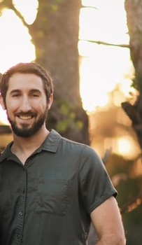

# Kyle Lambert

I am a bioinformatics and data science professional with 10 years of experience using genomics to solve real-world problems in biotech and agriculture. I’ve led cross-functional efforts, from building web platforms for microbial screening to architecting cloud-based pipelines that annotated over 200,000 genomes - resulting in faster data delivery, smarter R&D decisions, and new customer programs.

Over the years, I’ve developed and deployed scalable solutions using tools like AWS, Nextflow, Python, and SQL. I’ve also acted as a bridge between technical teams, scientists, and business stakeholders. Advising cross-functional teams on genomics capabilities, translating requirements into engineering roadmaps, or leading training to increase adoption of new tools.

I am driven by the opportunity to work at the intersection of science, software, and people. I strive to be a multiplier on teams, bringing an optimistic, growth mindset. I can support teams by applying problem-solving and coaching to genomics challenges, complex technical issues, or building infrastructure that enables insight generation or model development.

I’m now exploring opportunities to support innovation at the next generation of biotech companies.